# Day 11: Classification — In-Class Activity (Solutions)

Who is about to switch orange juice brands?

Instructor

```r
data(OJ)
```

## Part 1: The Baseline

### Task 1.1: How common is each brand?

```r
OJ %>%
  group_by(Purchase) %>%
  summarise(n = n()) %>%
  mutate(share = n / sum(n))
```

```
## # A tibble: 2 × 3
##   Purchase     n share
##   <fct>    <int> <dbl>
## 1 CH         653 0.610
## 2 MM         417 0.390
```

Citrus Hill is the more common brand, so the baseline always predicts `CH`. It is wrong exactly when the shopper buys Minute Maid, so its error rate is the share of `MM` purchases: **39%**. It finds **none** of the 417 Minute Maid buyers, so it’s useless for the coupon campaign.

### Task 1.2: Is loyalty a useful predictor?

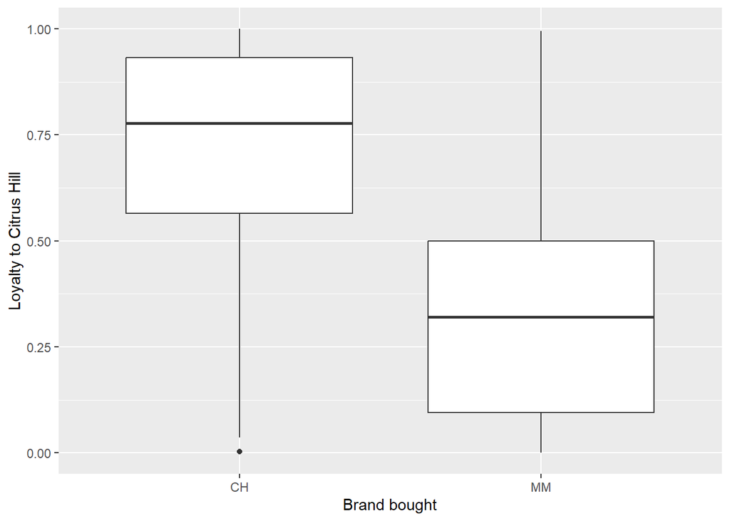

```r
ggplot(OJ, aes(Purchase, LoyalCH)) +
  geom_boxplot() +
  labs(x = "Brand bought", y = "Loyalty to Citrus Hill")
```

Minute Maid buyers tend to have **low** Citrus Hill loyalty (median around 0.3, versus about 0.8 for Citrus Hill buyers). The boxes barely overlap, so loyalty should separate the two groups well, though not perfectly: some loyal Citrus Hill customers still buy Minute Maid.

## Part 2: A Loyalty Rule

### Task 2.1: Make predictions

```r
OJ <- OJ %>%
  mutate(pred = ifelse(LoyalCH < 0.5, "MM", "CH"))

# Confusion matrix: rows = actual brand, columns = predicted brand
table(Actual = OJ$Purchase, Predicted = OJ$pred)
```

```
##       Predicted
## Actual  CH  MM
##     CH 553 100
##     MM 109 308
```

```r
# Error rate: share of rows where the prediction is wrong
OJ %>%
  summarise(error = mean(pred != Purchase))
```

```
##       error
## 1 0.1953271
```

The rule catches **308** Minute Maid buyers (`Purchase` = MM, `pred` = MM) and misses **109** (`Purchase` = MM, `pred` = CH). Its error rate is **19.5%**, about half the baseline’s 39%.

### Task 2.2: Recall, precision, specificity

Count the four cells with `summarise()`, then compute the rates from them with `mutate()`:

```r
rates <- OJ %>%
  summarise(tp = sum(pred == "MM" & Purchase == "MM"),
            fp = sum(pred == "MM" & Purchase == "CH"),
            fn = sum(pred == "CH" & Purchase == "MM"),
            tn = sum(pred == "CH" & Purchase == "CH")) %>%
  mutate(recall      = tp / (tp + fn),
         precision   = tp / (tp + fp),
         specificity = tn / (tn + fp))

rates
```

```
##    tp  fp  fn  tn    recall precision specificity
## 1 308 100 109 553 0.7386091  0.754902   0.8468606
```

- **Recall** (74%): of all the shoppers who bought Minute Maid, the rule would have reached about three in four.
- **Precision** (75%): of the shoppers the rule flags, about three in four really were buying Minute Maid.
- **Specificity** (85%): of the shoppers who bought Citrus Hill, the rule correctly leaves about 85% alone.

**Precision** tells the manager about waste: 1 − precision (25%) is the share of coupons that go to shoppers who were buying Citrus Hill anyway.

## Part 3: Choosing the Cutoff

### Task 3.1: Try other cutoffs

The blanks in the activity’s function are

- `fp <- sum(pred == "MM" & OJ$Purchase == "CH")`
- `fn <- sum(pred == "CH" & OJ$Purchase == "MM")`
- `recall = tp / (tp + fn)`
- `precision = tp / (tp + fp)`

Here is the same function written as a dplyr pipeline: `mutate()` makes the predictions for this cutoff, `summarise()` counts them, and `mutate()` turns the counts into rates.

```r
oj_rates <- function(cutoff) {
  OJ %>%
    mutate(pred = ifelse(LoyalCH < cutoff, "MM", "CH")) %>%
    summarise(cutoff = cutoff,
              error  = mean(pred != Purchase),
              tp     = sum(pred == "MM" & Purchase == "MM"),
              fp     = sum(pred == "MM" & Purchase == "CH"),
              fn     = sum(pred == "CH" & Purchase == "MM")) %>%
    mutate(recall    = tp / (tp + fn),
           precision = tp / (tp + fp))
}

# Stack the three one-row results into one table
bind_rows(oj_rates(0.3), oj_rates(0.5), oj_rates(0.7))
```

```
##   cutoff     error  tp  fp  fn    recall precision
## 1    0.3 0.2364486 199  35 218 0.4772182 0.8504274
## 2    0.5 0.1953271 308 100 109 0.7386091 0.7549020
## 3    0.7 0.2831776 391 277  26 0.9376499 0.5853293
```

The **0.5** cutoff has the lowest error rate of the three.

As the cutoff rises, **recall rises** (from about 48% to 94%) and **precision falls** (from 85% to 59%). A higher cutoff flags more shoppers. That reaches more of the real Minute Maid buyers, so recall goes up. But the extra shoppers it adds have higher loyalty, so they are more likely to be Citrus Hill buyers, and precision goes down.

### Task 3.2: Pick a cutoff for the campaign

If coupons are cheap and a missed Minute Maid buyer is a lost sale, **recall** matters most, so **0.7** is the best of the three: it reaches 94% of Minute Maid buyers. The price is that about 41% of coupons go to shoppers who were buying Citrus Hill anyway, which is fine when coupons cost little.

If each coupon were expensive, wasted coupons would matter more. That pushes toward higher **precision** and a lower cutoff, such as 0.3 or 0.5.

## Part 4: What Do the Coupons Earn?

### Task 4.1: Profit by cutoff

Every flagged shopper gets a coupon (cost $0.25), and each true positive earns $1.00, so

$$\text{Profit} = 1.00 \cdot TP - 0.25
\cdot (TP + FP)$$

The blank in the activity’s loop is `1.00 * tp - 0.25 * (tp + fp)`.

The dplyr way skips the loop. `cross_join()` makes one copy of the data for every cutoff (1,070 purchases × 9 cutoffs = 9,630 rows). Then `group_by(cutoff)` scores each copy separately, just like one pass of the loop.

```r
cutoffs <- tibble(cutoff = seq(0.1, 0.9, 0.1))

results <- OJ %>%
  cross_join(cutoffs) %>%
  mutate(pred = ifelse(LoyalCH < cutoff, "MM", "CH")) %>%
  group_by(cutoff) %>%
  summarise(error = mean(pred != Purchase),
            tp    = sum(pred == "MM" & Purchase == "MM"),
            fp    = sum(pred == "MM" & Purchase == "CH")) %>%
  mutate(profit = 1.00 * tp - 0.25 * (tp + fp))

results
```

```
## # A tibble: 9 × 5
##   cutoff error    tp    fp profit
##    <dbl> <dbl> <int> <int>  <dbl>
## 1    0.1 0.298   105     7    77
## 2    0.2 0.272   146    20   104.
## 3    0.3 0.236   199    35   140.
## 4    0.4 0.216   244    58   168.
## 5    0.5 0.195   308   100   206
## 6    0.6 0.230   352   181   219.
## 7    0.7 0.283   391   277   224
## 8    0.8 0.344   404   355   214.
## 9    0.9 0.432   407   452   192.
```

```r
# Sort so the most profitable cutoff is on top
results %>%
  arrange(desc(profit))
```

```
## # A tibble: 9 × 5
##   cutoff error    tp    fp profit
##    <dbl> <dbl> <int> <int>  <dbl>
## 1    0.7 0.283   391   277   224
## 2    0.6 0.230   352   181   219.
## 3    0.8 0.344   404   355   214.
## 4    0.5 0.195   308   100   206
## 5    0.9 0.432   407   452   192.
## 6    0.4 0.216   244    58   168.
## 7    0.3 0.236   199    35   140.
## 8    0.2 0.272   146    20   104.
## 9    0.1 0.298   105     7    77
```

Profit is highest at a cutoff of **0.7**, not at 0.5, the cutoff with the lowest error rate. The error rate counts a missed Minute Maid buyer and a wasted coupon as equally bad. Here a missed buyer costs $1.00 of lost profit, while a wasted coupon costs only $0.25. So it pays to flag more shoppers than the error rate would suggest.

In Part 2, 0.5 was just a natural-looking middle value. Nothing was being maximized. Here we try every cutoff and keep the one with the highest **profit**: we are **optimizing** a criterion we chose, by checking each candidate. Logistic regression (Day 12) also optimizes a criterion, but it uses it to choose its coefficients rather than a single cutoff.

## Bonus

### Bonus 1: Where is Minute Maid more likely?

```r
OJ %>%
  mutate(bin = cut(LoyalCH, breaks = seq(0, 1, 0.1), include.lowest = TRUE)) %>%
  group_by(bin) %>%
  summarise(n = n(), share_MM = mean(Purchase == "MM"))
```

```
## # A tibble: 10 × 3
##    bin           n share_MM
##    <fct>     <int>    <dbl>
##  1 [0,0.1]     112   0.938
##  2 (0.1,0.2]    54   0.759
##  3 (0.2,0.3]    68   0.779
##  4 (0.3,0.4]   118   0.653
##  5 (0.4,0.5]   117   0.513
##  6 (0.5,0.6]   118   0.271
##  7 (0.6,0.7]    81   0.284
##  8 (0.7,0.8]    91   0.143
##  9 (0.8,0.9]   100   0.03
## 10 (0.9,1]     211   0.0474
```

The share buying Minute Maid is above 50% in every bin up to 0.5 (51% in the 0.4–0.5 bin) and drops to 27% in the 0.5–0.6 bin. So it crosses 50% at about `LoyalCH` = 0.5, which is the cutoff with the lowest error rate in Task 3.1. That’s no coincidence: to make the fewest mistakes, predict whichever brand is more likely for that shopper.

### Bonus 2: One score for both kinds of mistakes

Same pipeline as Part 4, now counting all four cells and computing the scores with `mutate()`:

```r
scores <- OJ %>%
  cross_join(cutoffs) %>%
  mutate(pred = ifelse(LoyalCH < cutoff, "MM", "CH")) %>%
  group_by(cutoff) %>%
  summarise(error = mean(pred != Purchase),
            tp    = sum(pred == "MM" & Purchase == "MM"),
            fp    = sum(pred == "MM" & Purchase == "CH"),
            fn    = sum(pred == "CH" & Purchase == "MM"),
            tn    = sum(pred == "CH" & Purchase == "CH")) %>%
  mutate(recall      = tp / (tp + fn),
         precision   = tp / (tp + fp),
         specificity = tn / (tn + fp),
         balanced    = (recall + specificity) / 2,
         f1          = 2 * precision * recall / (precision + recall)) %>%
  select(cutoff, error, balanced, f1)

scores
```

```
## # A tibble: 9 × 4
##   cutoff error balanced    f1
##    <dbl> <dbl>    <dbl> <dbl>
## 1    0.1 0.298    0.621 0.397
## 2    0.2 0.272    0.660 0.501
## 3    0.3 0.236    0.712 0.611
## 4    0.4 0.216    0.748 0.679
## 5    0.5 0.195    0.793 0.747
## 6    0.6 0.230    0.783 0.741
## 7    0.7 0.283    0.757 0.721
## 8    0.8 0.344    0.713 0.687
## 9    0.9 0.432    0.642 0.638
```

- Lowest error rate: cutoff **0.5**.
- Highest balanced accuracy: cutoff **0.5**.
- Highest F1: cutoff **0.5**.
- Most profitable (Part 4): cutoff **0.7**.

Here the error rate, balanced accuracy, and F1 all pick the same cutoff. Only profit, which uses the dollar cost of each mistake, picks a different one.

Each score weighs the two kinds of mistakes differently. The error rate counts every mistake the same, so the more common class counts more just by being bigger. Balanced accuracy gives the two classes equal weight. F1 ignores the shoppers correctly left alone and looks only at how well we find Minute Maid buyers.

When one class is rare, as in `Default` (3%), these weightings are very different. The error rate barely cares about the few defaulters, so it favors flagging almost no one, while F1 cares only about them. That is why they picked different cutoffs on the slides. Here 39% of shoppers buy Minute Maid, so the error rate already gives them a lot of weight, and the three scores end up close enough to agree. Profit still differs because it weights a missed Minute Maid buyer ($1.00) four times as heavily as a wasted coupon ($0.25). When you know the costs, use them.

### Bonus 3: One question to think about

**Probably a bit less.** We picked the cutoff that earned the most on these 1,070 purchases, so it’s tuned partly to their quirks. Like training MSE on Day 9, a score measured on the data used to choose the model is optimistic. With a single cutoff the gap is likely small, because a one-number rule can’t overfit much. A flexible classifier could do much worse on new shoppers.